# Final Project Peer Review Draft

Molly Robertson

4/12/2020

# Final Project Peer Review Draft

Topic Overview: As an immunology and infectious disease major, I am interested in looking at various countries response to coronavirus from December 2019 to current. I would look at the total number of cases as they grew, as well as the response measurements and then the decline. Specifically, I would want to see which measures had the greatest impact on slowing down the case numbers, and identify which countries did a good job.

```r
#Load In Necessary Packages
library(DataComputing)
library(tidyr)
```

### Loading In Data

```r
#Rename Data Tables
GlobalRecovered <- read.csv("https://data.humdata.org/hxlproxy/data/download/time_series_covid19_recovered_global_iso3_regions.csv?dest=data_edit&filter01=merge&merge-url01=https%3A%2F%2Fdocs.google.com%2Fspreadsheets%2Fd%2Fe%2F2PACX-1vTglKQRXpkKSErDiWG6ycqEth32MY0reMuVGhaslImLjfuLU0EUgyyu2e-3vKDArjqGX7dXEBV8FJ4f%2Fpub%3Fgid%3D1326629740%26single%3Dtrue%26output%3Dcsv&merge-keys01=%23country%2Bname&merge-tags01=%23country%2Bcode%2C%23region%2Bmain%2Bcode%2C%23region%2Bmain%2Bname%2C%23region%2Bsub%2Bcode%2C%23region%2Bsub%2Bname%2C%23region%2Bintermediate%2Bcode%2C%23region%2Bintermediate%2Bname&filter02=merge&merge-url02=https%3A%2F%2Fdocs.google.com%2Fspreadsheets%2Fd%2Fe%2F2PACX-1vTglKQRXpkKSErDiWG6ycqEth32MY0reMuVGhaslImLjfuLU0EUgyyu2e-3vKDArjqGX7dXEBV8FJ4f%2Fpub%3Fgid%3D398158223%26single%3Dtrue%26output%3Dcsv&merge-keys02=%23adm1%2Bname&merge-tags02=%23country%2Bcode%2C%23region%2Bmain%2Bcode%2C%23region%2Bmain%2Bname%2C%23region%2Bsub%2Bcode%2C%23region%2Bsub%2Bname%2C%23region%2Bintermediate%2Bcode%2C%23region%2Bintermediate%2Bname&merge-replace02=on&merge-overwrite02=on&tagger-match-all=on&tagger-01-header=province%2Fstate&tagger-01-tag=%23adm1%2Bname&tagger-02-header=country%2Fregion&tagger-02-tag=%23country%2Bname&tagger-03-header=lat&tagger-03-tag=%23geo%2Blat&tagger-04-header=long&tagger-04-tag=%23geo%2Blon&header-row=1&url=https%3A%2F%2Fraw.githubusercontent.com%2FCSSEGISandData%2FCOVID-19%2Fmaster%2Fcsse_covid_19_data%2Fcsse_covid_19_time_series%2Ftime_series_covid19_recovered_global.csv")
GlobalDeaths<- read.csv("https://data.humdata.org/hxlproxy/data/download/time_series_covid19_deaths_global_iso3_regions.csv?dest=data_edit&filter01=merge&merge-url01=https%3A%2F%2Fdocs.google.com%2Fspreadsheets%2Fd%2Fe%2F2PACX-1vTglKQRXpkKSErDiWG6ycqEth32MY0reMuVGhaslImLjfuLU0EUgyyu2e-3vKDArjqGX7dXEBV8FJ4f%2Fpub%3Fgid%3D1326629740%26single%3Dtrue%26output%3Dcsv&merge-keys01=%23country%2Bname&merge-tags01=%23country%2Bcode%2C%23region%2Bmain%2Bcode%2C%23region%2Bmain%2Bname%2C%23region%2Bsub%2Bcode%2C%23region%2Bsub%2Bname%2C%23region%2Bintermediate%2Bcode%2C%23region%2Bintermediate%2Bname&filter02=merge&merge-url02=https%3A%2F%2Fdocs.google.com%2Fspreadsheets%2Fd%2Fe%2F2PACX-1vTglKQRXpkKSErDiWG6ycqEth32MY0reMuVGhaslImLjfuLU0EUgyyu2e-3vKDArjqGX7dXEBV8FJ4f%2Fpub%3Fgid%3D398158223%26single%3Dtrue%26output%3Dcsv&merge-keys02=%23adm1%2Bname&merge-tags02=%23country%2Bcode%2C%23region%2Bmain%2Bcode%2C%23region%2Bmain%2Bname%2C%23region%2Bsub%2Bcode%2C%23region%2Bsub%2Bname%2C%23region%2Bintermediate%2Bcode%2C%23region%2Bintermediate%2Bname&merge-replace02=on&merge-overwrite02=on&tagger-match-all=on&tagger-01-header=province%2Fstate&tagger-01-tag=%23adm1%2Bname&tagger-02-header=country%2Fregion&tagger-02-tag=%23country%2Bname&tagger-03-header=lat&tagger-03-tag=%23geo%2Blat&tagger-04-header=long&tagger-04-tag=%23geo%2Blon&header-row=1&url=https%3A%2F%2Fraw.githubusercontent.com%2FCSSEGISandData%2FCOVID-19%2Fmaster%2Fcsse_covid_19_data%2Fcsse_covid_19_time_series%2Ftime_series_covid19_deaths_global.csv")
GlobalConfirmed <- read.csv("https://data.humdata.org/hxlproxy/data/download/time_series_covid19_confirmed_global_iso3_regions.csv?dest=data_edit&filter01=merge&merge-url01=https%3A%2F%2Fdocs.google.com%2Fspreadsheets%2Fd%2Fe%2F2PACX-1vTglKQRXpkKSErDiWG6ycqEth32MY0reMuVGhaslImLjfuLU0EUgyyu2e-3vKDArjqGX7dXEBV8FJ4f%2Fpub%3Fgid%3D1326629740%26single%3Dtrue%26output%3Dcsv&merge-keys01=%23country%2Bname&merge-tags01=%23country%2Bcode%2C%23region%2Bmain%2Bcode%2C%23region%2Bmain%2Bname%2C%23region%2Bsub%2Bcode%2C%23region%2Bsub%2Bname%2C%23region%2Bintermediate%2Bcode%2C%23region%2Bintermediate%2Bname&filter02=merge&merge-url02=https%3A%2F%2Fdocs.google.com%2Fspreadsheets%2Fd%2Fe%2F2PACX-1vTglKQRXpkKSErDiWG6ycqEth32MY0reMuVGhaslImLjfuLU0EUgyyu2e-3vKDArjqGX7dXEBV8FJ4f%2Fpub%3Fgid%3D398158223%26single%3Dtrue%26output%3Dcsv&merge-keys02=%23adm1%2Bname&merge-tags02=%23country%2Bcode%2C%23region%2Bmain%2Bcode%2C%23region%2Bmain%2Bname%2C%23region%2Bsub%2Bcode%2C%23region%2Bsub%2Bname%2C%23region%2Bintermediate%2Bcode%2C%23region%2Bintermediate%2Bname&merge-replace02=on&merge-overwrite02=on&tagger-match-all=on&tagger-01-header=province%2Fstate&tagger-01-tag=%23adm1%2Bname&tagger-02-header=country%2Fregion&tagger-02-tag=%23country%2Bname&tagger-03-header=lat&tagger-03-tag=%23geo%2Blat&tagger-04-header=long&tagger-04-tag=%23geo%2Blon&header-row=1&url=https%3A%2F%2Fraw.githubusercontent.com%2FCSSEGISandData%2FCOVID-19%2Fmaster%2Fcsse_covid_19_data%2Fcsse_covid_19_time_series%2Ftime_series_covid19_confirmed_global.csv")
```

### Looking at Grand Totals by Worldwide Region

At the most basic level, I wanted to look at the total confirmed cases, deaths, and recovered based on regions. The regions in the dataset are Africa, Americas, Asia, Europe and Oceania. First, is the table and graph for confirmed cases, followed by deaths and then recovered.

```r
GlobalConfirmed1<-
GlobalConfirmed%>%
  group_by(Region.Name)%>%
  summarise(totalconfirmed = sum((X4.11.20)))
GlobalConfirmed1<-
 GlobalConfirmed1[-2,]
GlobalConfirmed1<-
  GlobalConfirmed1[-1,]
head(GlobalConfirmed1)
```

```
## # A tibble: 5 x 2
##   Region.Name totalconfirmed
##   <fct>                <int>
## 1 Africa               14215
## 2 Americas            609840
## 3 Asia                286456
## 4 Europe              852567
## 5 Oceania               7702
```

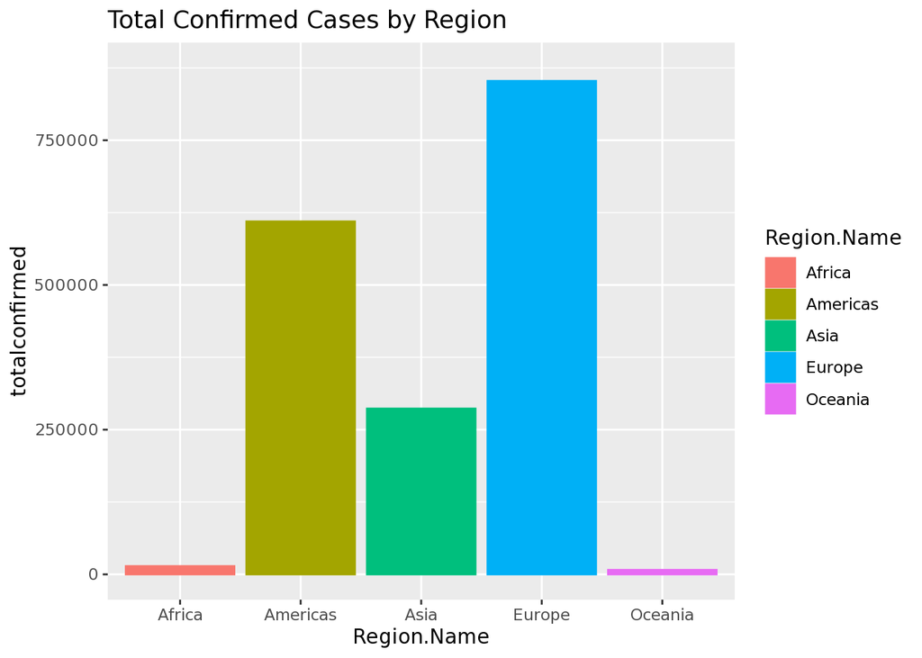

```r
GlobalConfirmed1%>%
  ggplot(aes(x=Region.Name, y=totalconfirmed)) +
  geom_bar(stat = "identity",aes(color=Region.Name, fill=Region.Name)) +
  ggtitle("Total Confirmed Cases by Region") +
  ylim(0, 875000)
```

Looking at the graph above, it appears as though Europe has the most cases with the Americas behind. These graphs need to be further divided to get the entire picture, as the majority of cases in the Americas are in the United States. Certain regions are dominated by certains countries.

```r
GlobalDeaths1<-
GlobalDeaths%>%
  group_by(Region.Name)%>%
  summarise(Total_Deaths = sum((X4.11.20)))
GlobalDeaths1<-
 GlobalDeaths1[-2,] #get rid of useless row
GlobalDeaths1<-
  GlobalDeaths1[-1,] #get rid of useless row
head(GlobalDeaths1)
```

```
## # A tibble: 5 x 2
##   Region.Name Total_Deaths
##   <fct>              <int>
## 1 Africa               745
## 2 Americas           23598
## 3 Asia               10588
## 4 Europe             73497
## 5 Oceania               61
```

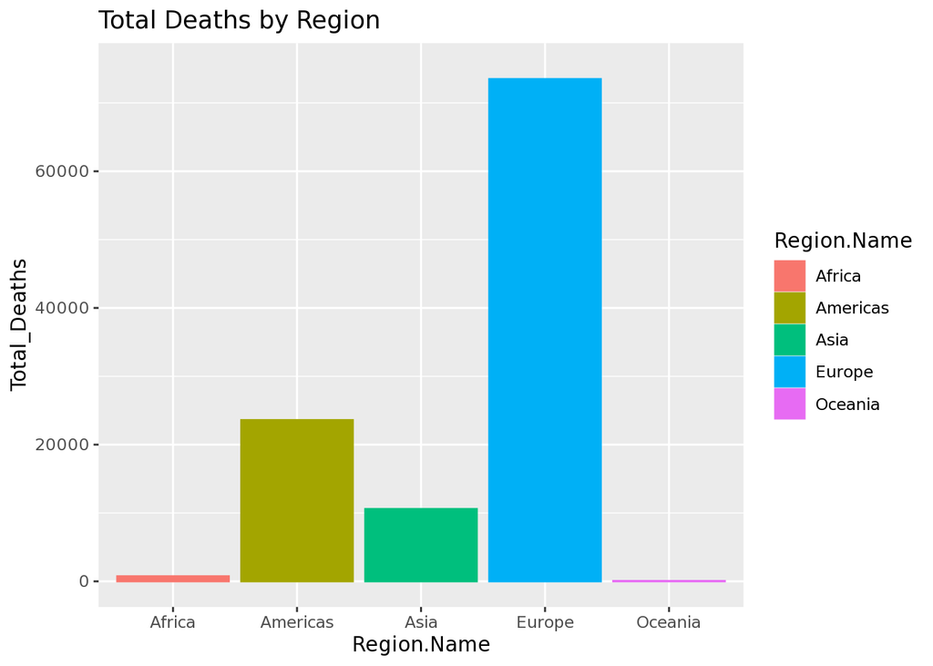

```r
GlobalDeaths1%>%
  ggplot(aes(x=Region.Name, y=Total_Deaths)) +
  geom_bar(stat = "identity",aes(color=Region.Name, fill=Region.Name)) +
  ggtitle("Total Deaths by Region") +
  ylim(0, 75000)
```

Unfortunately, Europe has the highest total number of deaths as well. It must be noted that many European countries are a few weeks ahead of the outbreak in the Americas, specifically the United States so this can change. These graphs also do not take into account total proportion of a population that have been infected, these are just pure counts.

```r
GlobalRecovered1<-
GlobalRecovered%>%
  group_by(Region.Name)%>%
  summarise(Total_Recovered = sum((X4.11.20)))
GlobalRecovered1<-
 GlobalRecovered1[-2,]
GlobalRecovered1<-
  GlobalRecovered1[-1,]
head(GlobalRecovered1)
```

```
## # A tibble: 5 x 2
##   Region.Name Total_Recovered
##   <fct>                 <int>
## 1 Africa                 2457
## 2 Americas              44274
## 3 Asia                 142464
## 4 Europe               210067
## 5 Oceania                2229
```

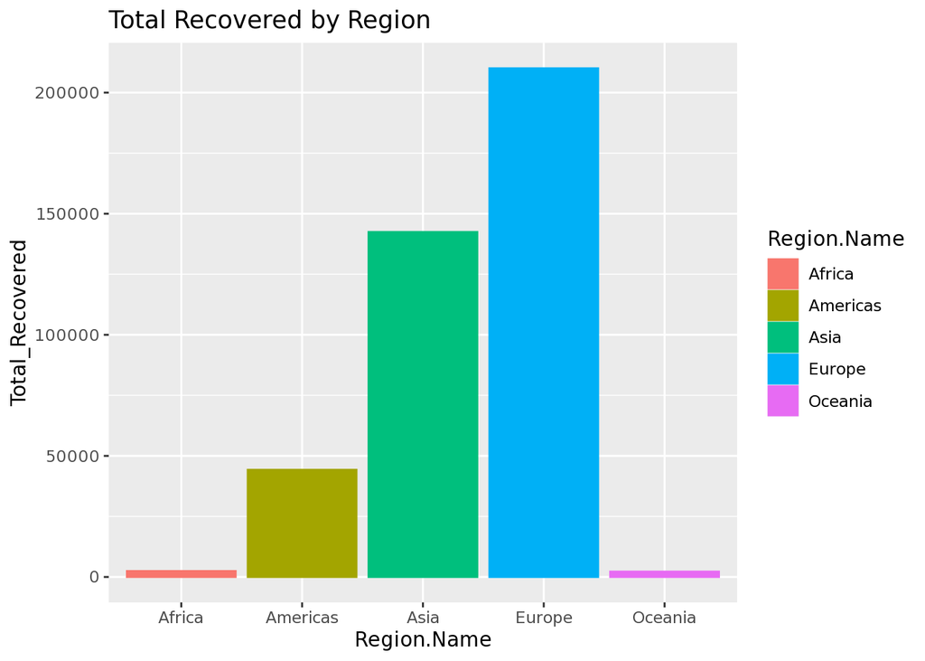

```r
GlobalRecovered1%>%
  ggplot(aes(x=Region.Name, y=Total_Recovered)) +
  geom_bar(stat = "identity",aes(color=Region.Name, fill=Region.Name)) +
  ggtitle("Total Recovered by Region")
```

Upliftingly, Europe does also have the highest amount of total recovered. Sadly, the Americas is still low on the recovered as we are nearing the peak of the outbreak in the United States. If the data we currently have is correct, the Asia region was able to contain their outbreak, mostly China, and keep deaths relatively low with recoveries high.

These graphs are fairly basic, and do not give us great insight into the outbreak. To further investigate this pandemic, it is necessary to look at a few countries from each of the regions, and their specific plan to combat the spread of the coronavirus.

### Data Wrangling: Separating the Totals by Country

First, I filtered the data tables so that only the name of the country and the confirmed cases for each date were included.

```r
GlobalConfirmedWide<-
 GlobalConfirmed[,-c(1,3,4,86,87,88,89,90,91,92)] #keeps only country and dates
head(GlobalConfirmedWide)
```

```
##   Country.Region X1.22.20 X1.23.20 X1.24.20 X1.25.20 X1.26.20 X1.27.20
## 1  #country+name       NA       NA       NA       NA       NA       NA
## 2    Afghanistan        0        0        0        0        0        0
## 3        Albania        0        0        0        0        0        0
## 4        Algeria        0        0        0        0        0        0
## 5        Andorra        0        0        0        0        0        0
## 6         Angola        0        0        0        0        0        0
##   X1.28.20 X1.29.20 X1.30.20 X1.31.20 X2.1.20 X2.2.20 X2.3.20 X2.4.20
## 1       NA       NA       NA       NA      NA      NA      NA      NA
## 2        0        0        0        0       0       0       0       0
## 3        0        0        0        0       0       0       0       0
## 4        0        0        0        0       0       0       0       0
## 5        0        0        0        0       0       0       0       0
## 6        0        0        0        0       0       0       0       0
##   X2.5.20 X2.6.20 X2.7.20 X2.8.20 X2.9.20 X2.10.20 X2.11.20 X2.12.20
```

[output cut: 62 more lines]

Afterwards, I combined the same countries together so that each case represented one country completley.

```r
GlobalConfirmedWide1<-
GlobalConfirmedWide%>%
  group_by(Country.Region)%>%
  summarise(S1.22.30 =sum(X1.22.20), S1.23.20 =sum(X1.23.20), S1.24.20 =sum(X1.24.20), S1.25.20 =sum(X1.25.20), S1.26.20 =sum(X1.26.20), S1.27.20 =sum(X1.27.20), S1.28.20 =sum(X1.28.20), S1.29.20 =sum(X1.29.20), S1.30.20 =sum(X1.30.20), S1.31.20 =sum(X1.31.20), S2.1.20 =sum(X2.1.20), S2.2.20 =sum(X2.2.20), S2.3.20 =sum(X2.3.20), S2.4.20 =sum(X2.4.20), S2.5.20 =sum(X2.5.20), S2.6.20 =sum(X2.6.20), S2.7.20 =sum(X2.7.20), S2.8.20 =sum(X2.8.20), S2.9.20 =sum(X2.9.20), S2.10.20 =sum(X2.10.20), S2.11.20 =sum(X2.11.20), S2.12.20 =sum(X2.12.20), S2.13.20 =sum(X2.13.20), S2.14.20 =sum(X2.14.20), S2.15.20 =sum(X2.15.20), S2.16.20 =sum(X2.16.20), S2.17.20 =sum(X2.17.20), S2.18.20 =sum(X2.18.20), S2.19.20 =sum(X2.19.20), S2.20.20 =sum(X2.20.20), S2.21.20 =sum(X2.21.20), S2.22.20 =sum(X2.22.20), S2.23.20 =sum(X2.23.20), S2.24.20 =sum(X2.24.20), S2.25.20 =sum(X2.25.20), S2.26.20 =sum(X2.26.20), S2.27.20 =sum(X2.27.20), S2.28.20 =sum(X2.28.20), S2.29.20 =sum(X2.29.20), S3.1.20 =sum(X3.1.20), S3.2.20 =sum(X3.2.20), S3.3.20 =sum(X3.3.20), S3.4.20 =sum(X3.4.20), S3.5.20 =sum(X3.5.20), S3.6.20 =sum(X3.6.20), S3.7.20 =sum(X3.7.20), S3.8.20 =sum(X3.8.20), S3.9.20 =sum(X3.9.20), S3.10.20 =sum(X3.10.20), S3.11.20 =sum(X3.11.20), S3.12.20 =sum(X3.12.20), S3.13.20 =sum(X3.13.20), S3.14.20 =sum(X3.14.20), S3.15.20 =sum(X3.15.20), S3.16.20 =sum(X3.16.20), S3.17.20 =sum(X3.18.20), S3.19.20 =sum(X3.19.20), S3.20.20 =sum(X3.20.20), S3.21.20 =sum(X3.21.20), S3.22.20 =sum(X3.22.20), S3.23.20 =sum(X3.23.20), S3.24.20 =sum(X3.24.20), S3.25.20 =sum(X3.25.20), S3.26.20 =sum(X3.26.20), S3.27.20 =sum(X3.27.20), S3.28.20 =sum(X3.28.20), S3.29.20 =sum(X3.29.20), S3.30.20 =sum(X3.30.20), S3.31.20 =sum(X3.31.20), S4.1.20 =sum(X4.1.20), S4.2.20 =sum(X4.2.20), S4.3.20 =sum(X4.3.20), S4.4.20 =sum(X4.4.20), S4.5.20 =sum(X4.5.20), S4.6.20 =sum(X4.6.20), S4.7.20 =sum(X4.7.20), S4.8.20 =sum(X4.8.20), S4.9.20 =sum(X4.9.20), S4.10.20 =sum(X4.10.20), S4.11.20 =sum(X4.11.20)) #to combine countries together that had various cases per province
```

Next, I wanted the dates as the cases and the countries as the variables, so I transposed the data table.

```r
GlobalConfirmedWide2<-
  t(GlobalConfirmedWide1)
GlobalConfirmedWide2<-
  GlobalConfirmedWide2[,-1] #removes blank first column
head(GlobalConfirmedWide2) #only showing output for this first one because they are long
```

[output not shown]

[output cut: 232 more lines]

[output not shown]

Now, I can use this data to create graphs that show changes in confirmed cases per country over time.

Afterwards, this same process was repeated for deaths.

```r
GlobalDeathsWide<-
  GlobalDeaths[,-c(1,3,4,86,87,88,89,90,91,92)] #keeps only country region and dates
```

```r
GlobalDeathsWide1<-
GlobalDeathsWide%>%
  group_by(Country.Region)%>%
  summarise(S1.22.30 =sum(X1.22.20), S1.23.20 =sum(X1.23.20), S1.24.20 =sum(X1.24.20), S1.25.20 =sum(X1.25.20), S1.26.20 =sum(X1.26.20), S1.27.20 =sum(X1.27.20), S1.28.20 =sum(X1.28.20), S1.29.20 =sum(X1.29.20), S1.30.20 =sum(X1.30.20), S1.31.20 =sum(X1.31.20), S2.1.20 =sum(X2.1.20), S2.2.20 =sum(X2.2.20), S2.3.20 =sum(X2.3.20), S2.4.20 =sum(X2.4.20), S2.5.20 =sum(X2.5.20), S2.6.20 =sum(X2.6.20), S2.7.20 =sum(X2.7.20), S2.8.20 =sum(X2.8.20), S2.9.20 =sum(X2.9.20), S2.10.20 =sum(X2.10.20), S2.11.20 =sum(X2.11.20), S2.12.20 =sum(X2.12.20), S2.13.20 =sum(X2.13.20), S2.14.20 =sum(X2.14.20), S2.15.20 =sum(X2.15.20), S2.16.20 =sum(X2.16.20), S2.17.20 =sum(X2.17.20), S2.18.20 =sum(X2.18.20), S2.19.20 =sum(X2.19.20), S2.20.20 =sum(X2.20.20), S2.21.20 =sum(X2.21.20), S2.22.20 =sum(X2.22.20), S2.23.20 =sum(X2.23.20), S2.24.20 =sum(X2.24.20), S2.25.20 =sum(X2.25.20), S2.26.20 =sum(X2.26.20), S2.27.20 =sum(X2.27.20), S2.28.20 =sum(X2.28.20), S2.29.20 =sum(X2.29.20), S3.1.20 =sum(X3.1.20), S3.2.20 =sum(X3.2.20), S3.3.20 =sum(X3.3.20), S3.4.20 =sum(X3.4.20), S3.5.20 =sum(X3.5.20), S3.6.20 =sum(X3.6.20), S3.7.20 =sum(X3.7.20), S3.8.20 =sum(X3.8.20), S3.9.20 =sum(X3.9.20), S3.10.20 =sum(X3.10.20), S3.11.20 =sum(X3.11.20), S3.12.20 =sum(X3.12.20), S3.13.20 =sum(X3.13.20), S3.14.20 =sum(X3.14.20), S3.15.20 =sum(X3.15.20), S3.16.20 =sum(X3.16.20), S3.17.20 =sum(X3.18.20), S3.19.20 =sum(X3.19.20), S3.20.20 =sum(X3.20.20), S3.21.20 =sum(X3.21.20), S3.22.20 =sum(X3.22.20), S3.23.20 =sum(X3.23.20), S3.24.20 =sum(X3.24.20), S3.25.20 =sum(X3.25.20), S3.26.20 =sum(X3.26.20), S3.27.20 =sum(X3.27.20), S3.28.20 =sum(X3.28.20), S3.29.20 =sum(X3.29.20), S3.30.20 =sum(X3.30.20), S3.31.20 =sum(X3.31.20), S4.1.20 =sum(X4.1.20), S4.2.20 =sum(X4.2.20), S4.3.20 =sum(X4.3.20), S4.4.20 =sum(X4.4.20), S4.5.20 =sum(X4.5.20), S4.6.20 =sum(X4.6.20), S4.7.20 =sum(X4.7.20), S4.8.20 =sum(X4.8.20), S4.9.20 =sum(X4.9.20), S4.10.20 =sum(X4.10.20), S4.11.20 =sum(X4.11.20)) #this added up countries together that had multiple cases due to various provinces
```

```r
GlobalDeathsWide2<-
  t(GlobalDeathsWide1)
GlobalDeathsWide2<-
  GlobalDeathsWide2[,-1] #removes blank first column
```

Lastly, this process was repeated for recovered cases.

```r
GlobalRecoveredWide<-
  GlobalRecovered[,-c(1,3,4,86,87,88,89,90,91,92)] #keeps only country region and dates
```

```r
GlobalRecoveredWide1<-
GlobalRecoveredWide%>%
  group_by(Country.Region)%>%
  summarise(S1.22.30 =sum(X1.22.20), S1.23.20 =sum(X1.23.20), S1.24.20 =sum(X1.24.20), S1.25.20 =sum(X1.25.20), S1.26.20 =sum(X1.26.20), S1.27.20 =sum(X1.27.20), S1.28.20 =sum(X1.28.20), S1.29.20 =sum(X1.29.20), S1.30.20 =sum(X1.30.20), S1.31.20 =sum(X1.31.20), S2.1.20 =sum(X2.1.20), S2.2.20 =sum(X2.2.20), S2.3.20 =sum(X2.3.20), S2.4.20 =sum(X2.4.20), S2.5.20 =sum(X2.5.20), S2.6.20 =sum(X2.6.20), S2.7.20 =sum(X2.7.20), S2.8.20 =sum(X2.8.20), S2.9.20 =sum(X2.9.20), S2.10.20 =sum(X2.10.20), S2.11.20 =sum(X2.11.20), S2.12.20 =sum(X2.12.20), S2.13.20 =sum(X2.13.20), S2.14.20 =sum(X2.14.20), S2.15.20 =sum(X2.15.20), S2.16.20 =sum(X2.16.20), S2.17.20 =sum(X2.17.20), S2.18.20 =sum(X2.18.20), S2.19.20 =sum(X2.19.20), S2.20.20 =sum(X2.20.20), S2.21.20 =sum(X2.21.20), S2.22.20 =sum(X2.22.20), S2.23.20 =sum(X2.23.20), S2.24.20 =sum(X2.24.20), S2.25.20 =sum(X2.25.20), S2.26.20 =sum(X2.26.20), S2.27.20 =sum(X2.27.20), S2.28.20 =sum(X2.28.20), S2.29.20 =sum(X2.29.20), S3.1.20 =sum(X3.1.20), S3.2.20 =sum(X3.2.20), S3.3.20 =sum(X3.3.20), S3.4.20 =sum(X3.4.20), S3.5.20 =sum(X3.5.20), S3.6.20 =sum(X3.6.20), S3.7.20 =sum(X3.7.20), S3.8.20 =sum(X3.8.20), S3.9.20 =sum(X3.9.20), S3.10.20 =sum(X3.10.20), S3.11.20 =sum(X3.11.20), S3.12.20 =sum(X3.12.20), S3.13.20 =sum(X3.13.20), S3.14.20 =sum(X3.14.20), S3.15.20 =sum(X3.15.20), S3.16.20 =sum(X3.16.20), S3.17.20 =sum(X3.18.20), S3.19.20 =sum(X3.19.20), S3.20.20 =sum(X3.20.20), S3.21.20 =sum(X3.21.20), S3.22.20 =sum(X3.22.20), S3.23.20 =sum(X3.23.20), S3.24.20 =sum(X3.24.20), S3.25.20 =sum(X3.25.20), S3.26.20 =sum(X3.26.20), S3.27.20 =sum(X3.27.20), S3.28.20 =sum(X3.28.20), S3.29.20 =sum(X3.29.20), S3.30.20 =sum(X3.30.20), S3.31.20 =sum(X3.31.20), S4.1.20 =sum(X4.1.20), S4.2.20 =sum(X4.2.20), S4.3.20 =sum(X4.3.20), S4.4.20 =sum(X4.4.20), S4.5.20 =sum(X4.5.20), S4.6.20 =sum(X4.6.20), S4.7.20 =sum(X4.7.20), S4.8.20 =sum(X4.8.20), S4.9.20 =sum(X4.9.20), S4.10.20 =sum(X4.10.20), S4.11.20 =sum(X4.11.20)) #this added up countries together that had multiple cases due to various provinces
```

```r
GlobalRecoveredWide2<-
  t(GlobalRecoveredWide1)
GlobalRecoveredWide2<-
  GlobalRecoveredWide2[,-1]
```

### Comparing Countries

For right now, I am going to only look at three different countries responses to coronavirus: China, South Korea, and the United States.

To begin, the three countries have to be filtered from the rest of the data tables.

I have not finished yet, but I plan on creating a few graphs of China, South Korea, and the United States that show the change in total deaths, recovered patients, and confirmed cases. Once I do that, I am going to add in vertical bars that show when different measures were implemented, such as self-quarantining or widespread testing, and show how each impacted these numbers in the countries. After that is completed, I am going to create a heat map of the world which shows which countries have the most cases as of April 11th, 2020. By comparing the different strategies, I will hope to evaluate their usefulness.

Would love feedback on anything else I should include!

.